# EP05-respuesta-equipo-9

2025-09-24

## Contexto

En una emocionante competencia de cubos Rubik, participantes de Chile, Argentina, Colombia, Uruguay, Perú y Ecuador demostraron su destreza en resolver tres tipos de cubos: 2x2x2, 3x3x3 y Megaminx.

Después del torneo, un grupo de investigadores de la Asociación Mundial del Cubo, interesado en los tiempos que hicieron las jugadoras y los jugadores en la competencia, decidieron estudiar si el país y el tipo de cubo usado en cada prueba tienen influencia en los segundos que se tardan en resolverlos. Para ello usaron una muestra aleatoria de los datos de la competencia, en la cual participaron más de 2.000 personas, con las siguientes variables:

```r
library(DescTools)
library(dplyr)
library(ez)
library(ggpubr)
library(tidyr)
library(DT)

variables <- data.frame(c("id","país","tipo","tiempo"),c("Identificador único de cada participante.","País que representa cada participante (Argentina, Chile, Colombia, Ecuador, Perú, Uruguay).","Tipo de cubo usado en la prueba (2x2x2, 3x3x3, Megaminx).","Tiempo, en segundos, que toma al participante en resolver el cubo de la prueba."))
datatable(variables,rownames = variables,colnames = c("Variable","Descripción"))
```

| Variable | Descripción |
| --- | --- |
| id | Identificador único de cada participante. |
| país | País que representa cada participante (Argentina, Chile, Colombia, Ecuador, Perú, Uruguay). |
| tipo | Tipo de cubo usado en la prueba (2x2x2, 3x3x3, Megaminx). |
| tiempo | Tiempo, en segundos, que toma al participante en resolver el cubo de la prueba. |

**Lectura de datos**

```r
datos <- read.csv2("EP05 Datos.csv")
chile <- datos[which(datos$pais == "Chile" & datos$tipo == "Megaminx"),]
peru <- datos[which(datos$pais == "Perú" & datos$tipo == "Megaminx"),]
argentina <- datos[which(datos$pais == "Argentina" & datos$tipo == "Megaminx"),]

#Vectores de tiempos por país a utilizar próximamente

tiempos_chile <- as.numeric(chile$tiempo)
tiempos_peru <- as.numeric(peru$tiempo)
tiempos_argentina <- as.numeric(argentina$tiempo)
```

## Pregunta

*¿Existen diferencias en el tiempo de resolución de cubos Megaminx entre participantes de Chile, Argentina y Perú?*

Hipótesis a contrastar:

- $$H_0: \mu_{CH} = \mu_{AR} =
  \mu_{PE}$$
- $$H_A: \exists i,j | \mu_i \neq
  \mu_j$$

En palabras:

- $H_0:$ La media del tiempo de resolución es igual para los tres países
- $H_A:$ La media del tiempo de resolución difiere para el menos dos países

Además, definiremos un nivel de signficancia de un 0.05

```r
alfa <- 0.05
```

## Verficar condiciones

Para utilizar la prueba ANOVA de una vía es necesario que se cumplan las siguientes condiciones

- La escala con que se mide la variable dependiente tiene las propiedades de una escala de intervalos iguales.

  *Dado que el tiempo es una medidad universal y los tres países son medidos con la misma unidad, se asegura que la escala con la que se mide tiene las propiedades de intervalos. Es decir, un incremento o decremento de una unidad significa lo mismo en todos los países.*
- Las k muestras son obtenidas de manera aleatoria e independiente desde la(s) población(es) de origen.

  *Ya que la cantidad de individuos en cada muestra constituyen **menos del 10% de la población (2000 personas)**, y se asume que el desempeño de cada competidor no influye en el de otro, es razonable concluir que las 3 muestras son obtenidas de manera aleatoria e independiente.*
- Se puede suponer razonablemente que la(s) población(es) de origen sigue(n) una distribución normal. Para esta condicion, harémos los siguientes test de normalidad:

Para verificar lo anterior, realizamos pruebas de normalidad de shapiro, así como gráficos Q-Q. Considerando ambos resultados, podremos concluir sobre la normalidad de las poblaciones.

```r
norm_chile <- shapiro.test(chile$tiempo)
print(norm_chile)
```

```
##
##  Shapiro-Wilk normality test
##
## data:  chile$tiempo
## W = 0.96646, p-value = 0.263
```

```r
norm_peru <- shapiro.test(peru$tiempo)
print(norm_peru)
```

```
##
##  Shapiro-Wilk normality test
##
## data:  peru$tiempo
## W = 0.96088, p-value = 0.1688
```

```r
norm_arg <- shapiro.test(argentina$tiempo)
print(norm_arg)
```

```
##
##  Shapiro-Wilk normality test
##
## data:  argentina$tiempo
## W = 0.95731, p-value = 0.1551
```

**Gráficos Q-Q**

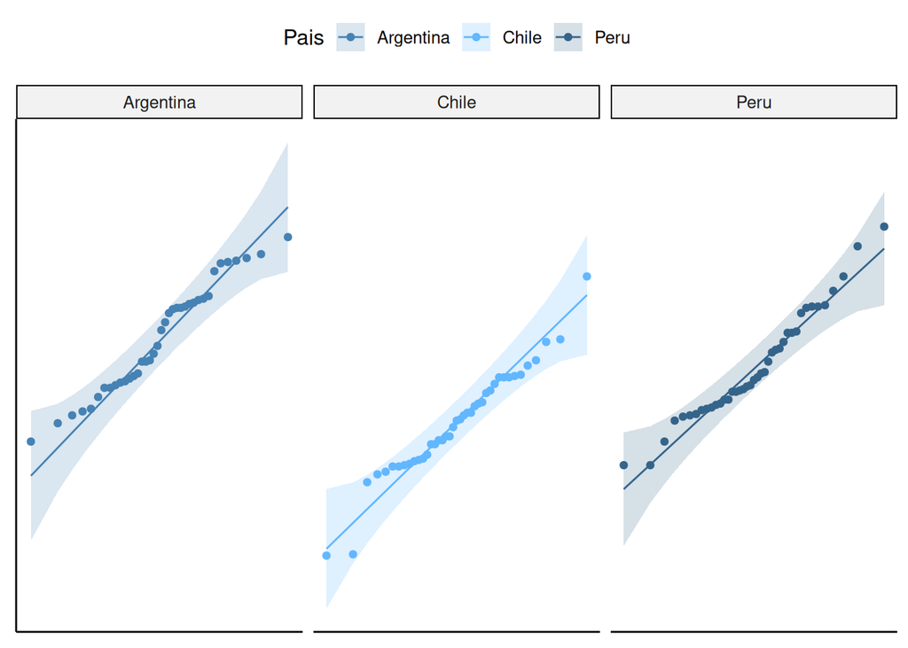

```r
datos_largos <- bind_rows(
  data.frame(Pais = "Chile", Tiempo = tiempos_chile),
  data.frame(Pais = "Peru", Tiempo = tiempos_peru),
  data.frame(Pais = "Argentina", Tiempo = tiempos_argentina)
) |>
  mutate(Instancia = factor(row_number())) |>
  group_by(Pais) |>
  mutate(Pais = factor(Pais)) #Convierte país en un tipo de categoría

library(ggpubr)

# Comprobar la condición de normalidad con gráficos Q-Q
g1 <- ggqqplot(datos_largos, x = "Tiempo", y = "Pais", color = "Pais", alpha = 0.7,
               palette = c("steelblue", "steelblue1", "steelblue4"))

g1 <- g1 + facet_wrap(~ Pais)
g1 <- g1 + rremove("x.ticks") + rremove("x.text")
g1 <- g1 + rremove("y.ticks") + rremove("y.text")
g1 <- g1 + rremove("axis.title")

print(g1)
```

Las pruebas de **shapiro wilk** nos entregan p values que nos indican que **no existe evidencia suficiente para negar que cada una de las muestras sigue una distribución normal**. Además, para mostrar también esto de manera gráfica y estar seguros de cumplir con la condición de normalidad, se construyó un qqplot de cada uno de los países, llegando a la misma conclusión.

- Si las muestras provienen de más de una población, estas poblaciones tienen la misma varianza.

Para comprobar esto, se hará una **prueba para verificar la homogeneidad de las varianzas**, la que consiste en ver que se cumpla que la razón entre la maxima y la minima varianza muestral no sea mayor a 1.5.

```r
var_chile <- var(chile$tiempo)
var_peru <- var(peru$tiempo)
var_arg <- var(argentina$tiempo)

vars <- c(var_chile,var_peru,var_arg)

var_max <- max(vars)
var_min <- min(vars)

razon <- var_max / var_min

if(razon > 1.5){
  cat("Las varianzas no son parecidas")
}else{
  cat("Las varianzas son parecidas")
}
```

```
## Las varianzas son parecidas
```

**En consecuencia, se puede apreciar que se cumple la condición de homogeneidad para estos datos.**

Ahora se aplicará el procedimiento ANOVA, y debido a que los datos no se encuentran balanceados, se usará la prueba ezANOVA.

```r
prueba_ez <- ezANOVA(data = datos_largos, dv = Tiempo, between = Pais, detailed = TRUE, wid = Instancia, return_aov = TRUE)
```

```
## Coefficient covariances computed by hccm()
```

```r
print(prueba_ez)
```

```
## $ANOVA
##   Effect DFn DFd     SSn      SSd        F            p p<.05       ges
## 1   Pais   2 117 8.61415 20.19043 24.95874 9.386747e-10     * 0.2990549
##
## $`Levene's Test for Homogeneity of Variance`
##   DFn DFd        SSn      SSd         F         p p<.05
## 1   2 117 0.05721875 7.032928 0.4759464 0.6224944
##
## $aov
## Call:
##    aov(formula = formula(aov_formula), data = data)
##
## Terms:
##                     Pais Residuals
## Sum of Squares   8.61415  20.19043
## Deg. of Freedom        2       117
##
## Residual standard error: 0.4154128
## Estimated effects may be unbalanced
```

Como complemento a esto, podemos construir un gráfico para visualizar el tamaño del efecto:

```r
# Obtener, cambiar colores y mostrar el gráfico del tamaño del efecto
g2 <- ezPlot(data = datos_largos, dv = Tiempo, wid = Instancia, between = Pais,
             y_lab = "Tiempo promedio", x = Pais)
```

```
## Coefficient covariances computed by hccm()
```

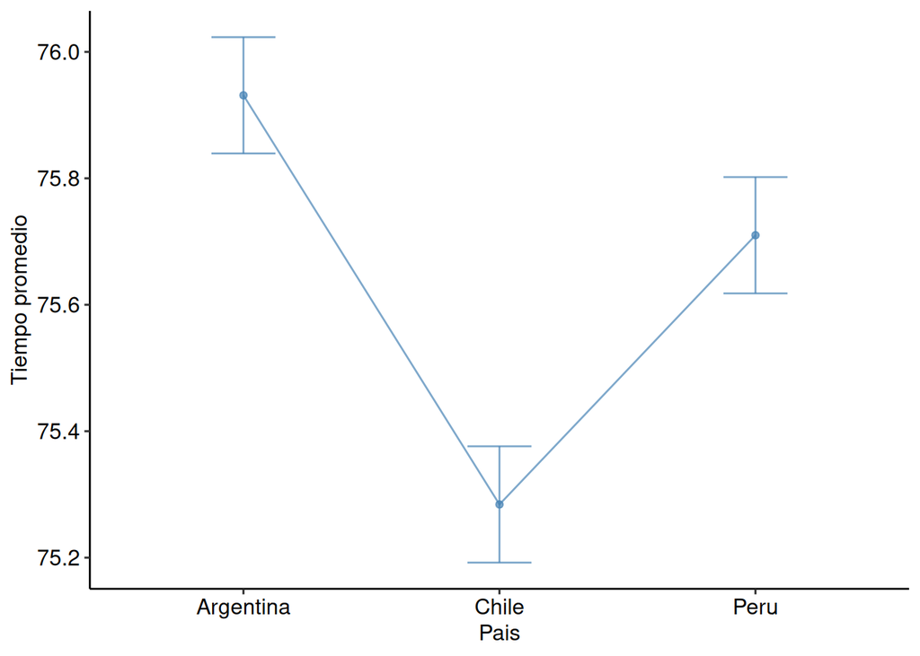

```r
g2 <- g2 + theme_pubr()
g2[["layers"]][[1]][["aes_params"]] <- list(colour = "steelblue", alpha = 0.7) # puntos
g2[["layers"]][[2]][["aes_params"]] <- list(colour = "steelblue", alpha = 0.7) # líneas
g2[["layers"]][[3]][["aes_params"]] <- list(colour = "steelblue", alpha = 0.7) # error

print(g2)
```

Para finalizar, en este caso particular, y debido a los resultados obtenidos del test de ANOVA, corresponde aplicar un procedimiento Post-hoc, para conocer de mejor forma cuáles son los pares discordantes, y cuáles son los mejores y peores tiempos medios.

## Procedimientos Post-hoc

```r
F_star <- qf(1 - alfa, 2, 357, lower.tail = TRUE)
F_star
```

```
## [1] 3.021012
```

Realizamos una tabla de contrastes entre los tres grupos

```r
contrastes <- matrix ( c (1 , -1 , 0 , 1 , 0 , -1 , 0 , 1 , -1 , 1 , -0.5 , -0.5 , -0.5 , 1 , -0.5 , -0.5 , -0.5 , 1) ,ncol = 3 , byrow = TRUE )
contrastes <- t(contrastes)
```

Luego, realizamos la prueba de Scheffe

```r
st <- ScheffeTest(x=prueba_ez$aov, which = "Pais", contrasts = contrastes, conf.level = 1 - alfa)
st
```

```
##
##   Posthoc multiple comparisons of means: Scheffe Test
##     95% family-wise confidence level
##
## $Pais
##                            diff      lwr.ci     upr.ci    pval
## Argentina-Chile       0.6471694  0.41523789  0.8791010 1.9e-09 ***
## Argentina-Peru        0.2213158 -0.01061577  0.4532473  0.0650 .
## Chile-Peru           -0.4258537 -0.65333883 -0.1983685 5.1e-05 ***
## Argentina-Chile,Peru  0.4342426  0.23211674  0.6363685 3.0e-06 ***
## Chile-Argentina,Peru -0.5365116 -0.73481136 -0.3382117 5.4e-09 ***
## Peru-Argentina,Chile  0.1022689 -0.09603087  0.3005687  0.4440
##
## ---
## Signif. codes:  0 '***' 0.001 '**' 0.01 '*' 0.05 '.' 0.1 ' ' 1
```